# Anàlisi de dades amb R

Malu Calle

[figure not shown]

# 1 Introdució

En aquest tutorial revisarem els principals mètodes d’anàlisi de dades amb R. Per il·lustrar els procediments utilitzarem el conjunt de dades, “nadons.xlsx”, que podeu trobar aquí: https://malucalle.github.io/statistical-pills/nadons.xlsx

# 2 Preparar les dades

## 2.1 Estructurar bé les dades

Abans de començar una anàlisi de dades cal plantejar-se si les dades estan ben estructurades:

- Quins són els “individus” o “casos” de l’estudi?
- Quina informació recollim de cada individu? variables
- Una fila no pot contenir informació de més d’un individu
- Les dades han de tenir una estructura quadrada:

  ```
    Files = individus = casos

    Columnes = variables
  ```

## 2.2 Especificar la carpeta de treball

Especificar la carpeta de treball directament des de RStudio:

```
Session -> Set working directory -> choose directory
```

## 2.3 Importar les dades a R

Importar les dades a R directament des de RStudio

```
File -> Import Dataset

-> From Excel... -> Browse   (carregueu el fitxer "nadons.xlsx")

Comprovar que les variables numèriques s'importen com a numèriques o double
```

També es pot fer amb codi d’R amb la llibreria d’R **readxl**:

Instal·lar la llibreria. Només cal fer-ho una vegada. El nom ha d’anar entre cometes:

```r
install.packages("readxl")
```

Activar la llibreria sempre que es comença una nova sessió d’R. El nom no cal que estigui entre cometes:

```r
library(readxl)
```

Utilitzem la funció read_excel per carregar les dades:

```r
nadons <- read_excel("nadons.xlsx")
```

**Mirar la taula de dades que hem carregat:**

Clicar sobre el nom de la taula a la finestra “Environment” i comprovar que les dades s’han carregat bé. També es pot fer amb codi d’R:

```r
View(nadons)
```

Canviarem el nom de la taula a “data”:

```r
data<-nadons
```

I ara eliminem (rm=remove) la taula “nadons”:

```r
rm(nadons)
```

**Mirar l’estructura de les dades i el tipus de cada variable:**

```r
str(data)
```

```
## tibble [200 x 11] (S3: tbl_df/tbl/data.frame)
##  $ id               : chr [1:200] "001" "002" "003" "004" ...
##  $ nado_sexe        : chr [1:200] "nen" "nena" "nen" "nena" ...
##  $ nado_pes         : num [1:200] 3.83 3.62 4.15 2.67 3.76 3.77 3.11 3.49 2.37 3.13 ...
##  $ nado_baix_pes    : num [1:200] 0 0 0 0 0 0 0 0 1 0 ...
##  $ setmanes_gestacio: num [1:200] 40 38 41 39 39 40 40 37 40 39 ...
##  $ prematur         : chr [1:200] "no" "no" "no" "no" ...
##  $ edat_mare        : num [1:200] 1 2 2 2 2 1 2 1 2 2 ...
##  $ nombre_visites   : num [1:200] 2 4 2 2 3 3 3 4 10 1 ...
##  $ mare_fumadora    : chr [1:200] "no" "no" "no" "si" ...
##  $ mare_pes_ini     : num [1:200] 62 56 66 63 76 62 63 70 70 63 ...
##  $ mare_pes_fi      : num [1:200] 74 73 80 76 95 79 81 78 81 76 ...
```

Veiem que totes les variables s’han importat com a numèriques (num) o caràcter (chr)

## 2.4 Resum numèric conjunt de totes les variables

```r
summary(data)
```

```
##       id             nado_sexe            nado_pes     nado_baix_pes
##  Length:200         Length:200         Min.   :1.510   Min.   :0.000
##  Class :character   Class :character   1st Qu.:2.748   1st Qu.:0.000
##  Mode  :character   Mode  :character   Median :3.230   Median :0.000
##                                        Mean   :3.201   Mean   :0.185
##                                        3rd Qu.:3.612   3rd Qu.:0.000
##                                        Max.   :5.250   Max.   :1.000
##  setmanes_gestacio   prematur           edat_mare     nombre_visites
##  Min.   :22.00     Length:200         Min.   :1.000   Min.   : 0.00
##  1st Qu.:36.00     Class :character   1st Qu.:1.000   1st Qu.: 2.00
##  Median :38.00     Mode  :character   Median :2.000   Median : 3.00
##  Mean   :37.37                        Mean   :1.825   Mean   : 3.72
##  3rd Qu.:40.00                        3rd Qu.:2.000   3rd Qu.: 4.00
##  Max.   :44.00                        Max.   :3.000   Max.   :20.00
##  mare_fumadora       mare_pes_ini  mare_pes_fi
##  Length:200         Min.   :50    Min.   :63.00
##  Class :character   1st Qu.:62    1st Qu.:75.00
##  Mode  :character   Median :65    Median :79.00
##                     Mean   :65    Mean   :78.64
##                     3rd Qu.:69    3rd Qu.:82.00
##                     Max.   :77    Max.   :95.00
```

Com es pot veure el resum de les dades categòriques no es adequat i cal preparar-les per l’anàlisi

## 2.5 Preparar les dades categòriques

Amb la funció `factor()` preparem les dades categòriques per l’anàlisi:

**Variables caràcter (chr):**

```r
data$prematur<-factor(data$prematur)

data$nado_sexe<-factor(data$nado_sexe)

data$mare_fumadora<-factor(data$mare_fumadora)
```

**Variables numèriques (num) que en realitat són categòriques:**

Cal especificar què representa cada valor:

```r
data$edat_mare<-factor(data$edat_mare, levels = c(1,2,3), labels = c("<=30", "30-40", ">40"))

data$nado_baix_pes<-factor(data$nado_baix_pes, levels = c(0,1), labels = c("no", "si"))
```

**Tornem a fer un resum numèric conjunt de totes les variables:**

```r
summary(data)
```

```
##       id            nado_sexe     nado_pes     nado_baix_pes setmanes_gestacio
##  Length:200         nen : 94   Min.   :1.510   no:163        Min.   :22.00
##  Class :character   nena:106   1st Qu.:2.748   si: 37        1st Qu.:36.00
##  Mode  :character              Median :3.230                 Median :38.00
##                                Mean   :3.201                 Mean   :37.37
##                                3rd Qu.:3.612                 3rd Qu.:40.00
##                                Max.   :5.250                 Max.   :44.00
##  prematur edat_mare   nombre_visites  mare_fumadora  mare_pes_ini
##  no:141   <=30 : 65   Min.   : 0.00   no:160        Min.   :50
##  si: 59   30-40:105   1st Qu.: 2.00   si: 40        1st Qu.:62
##           >40  : 30   Median : 3.00                 Median :65
##                       Mean   : 3.72                 Mean   :65
##                       3rd Qu.: 4.00                 3rd Qu.:69
##                       Max.   :20.00                 Max.   :77
##   mare_pes_fi
##  Min.   :63.00
##  1st Qu.:75.00
##  Median :79.00
##  Mean   :78.64
##  3rd Qu.:82.00
##  Max.   :95.00
```

## 2.6 Gràfics amb R

Utilitzarem la llibreria **ggpubr** que permet fer gràfics més interessants que els que es poden fer amb les funcions bàsiques d’R.

Podeu veure exemples dels gràfics més importants en aquest tutorial: https://malucalle.github.io/statistical-pills/nice-plots-with-r.html

```r
#install.packages("ggpubr")

library(ggpubr)   # activar la llibreria. S'ha de fer cada cop que s'engega R
```

## 2.7 Histogrames de les variables numèriques

**Exemple: Setmanes de gestació:**

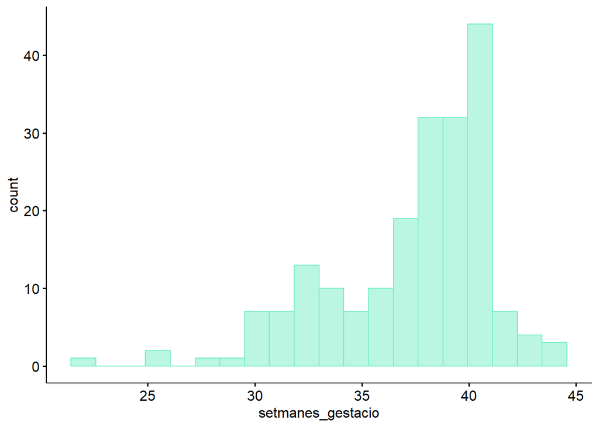

```r
gghistogram(data, x="setmanes_gestacio",
            bins = 20,
            color="aquamarine2", fill="aquamarine2")
```

**Podeu representar totes les variables numèriques de cop:**

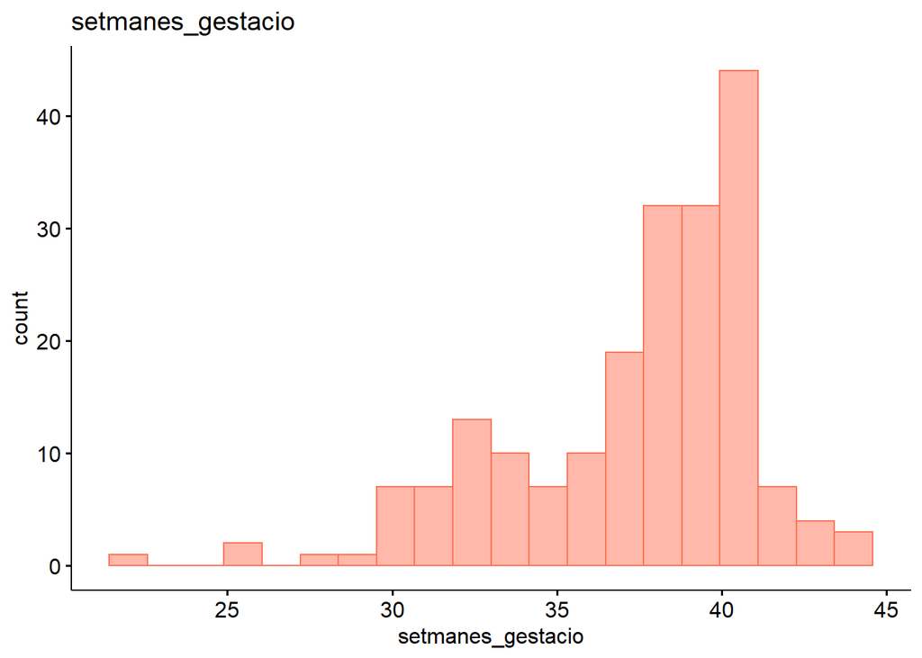

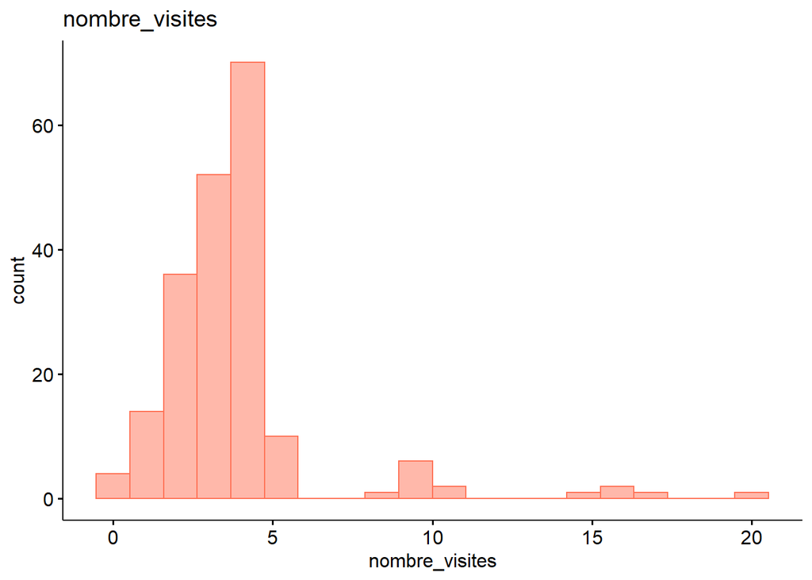

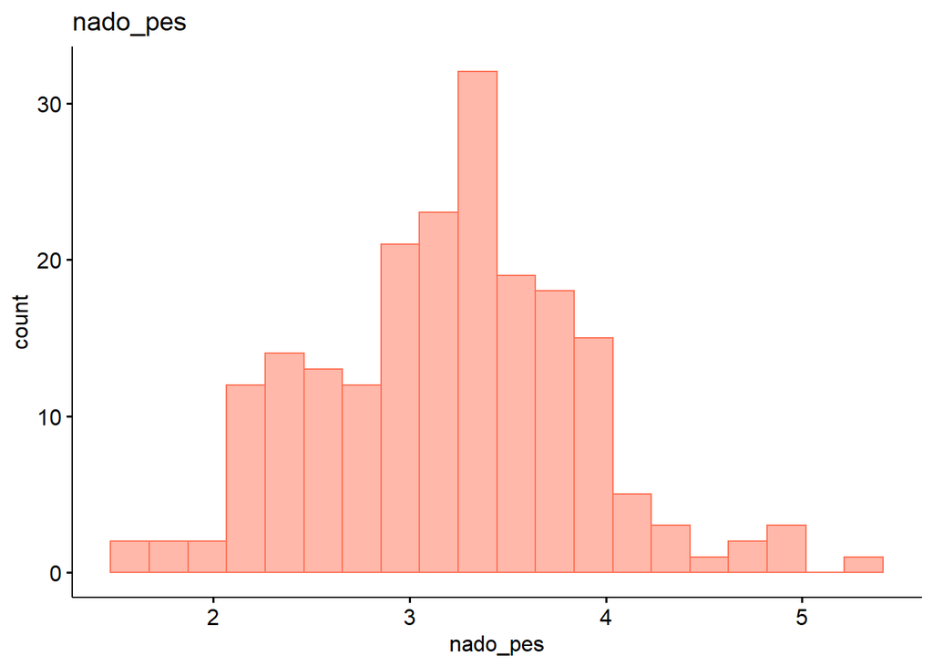

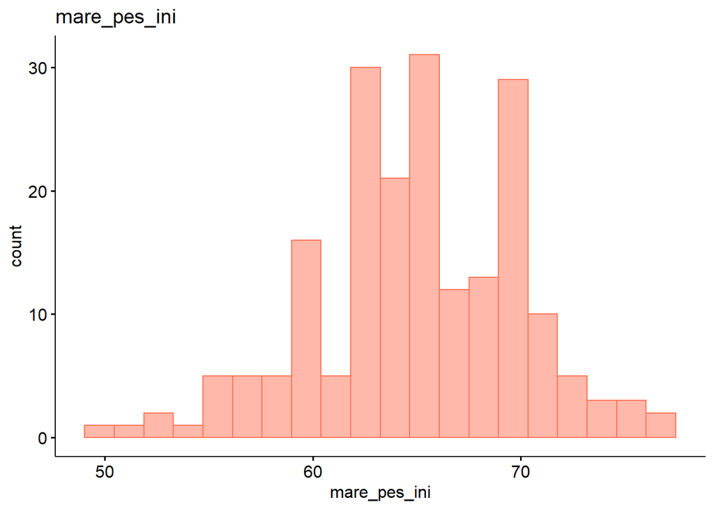

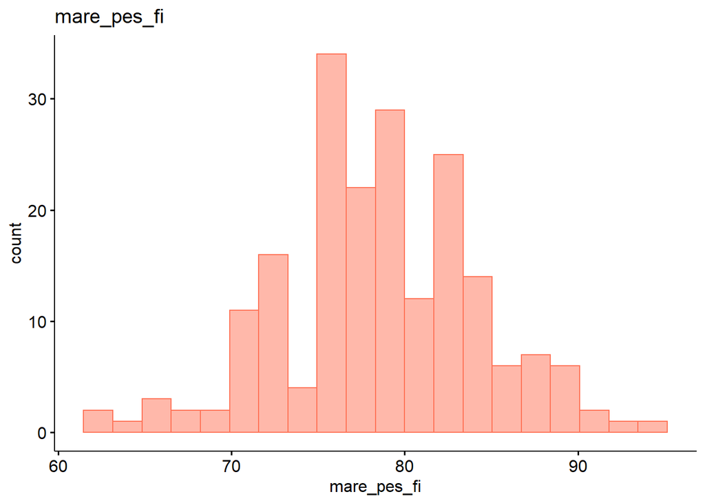

```r
p<-gghistogram(data,
    x=c("setmanes_gestacio","nombre_visites","nado_pes","mare_pes_ini","mare_pes_fi"),          bins = 20,
    color = "coral1", fill = "coral1")
p
```

## 2.8 Boxplots de les variables numèriques

**Exemple: Setmanes de gestació:**

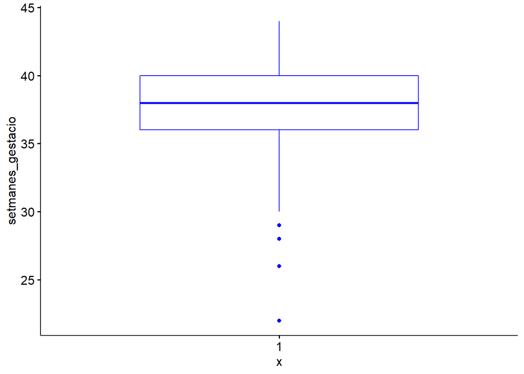

```r
p<-ggboxplot(data, y="setmanes_gestacio", color = "blue")
p
```

## 2.9 Diagrames de barres de les variables categòriques

**Exemple: Edat de la mare:**

Per poder representar les variables categòriques primer hem de fer la taula de freqüències:

```r
table(data$edat_mare)
```

```
##
##  <=30 30-40   >40
##    65   105    30
```

i la taula de freqüències relatives:

```r
prop.table(table(data$edat_mare))
```

```
##
##  <=30 30-40   >40
## 0.325 0.525 0.150
```

Gràfic de barres de la taula de freqüències:

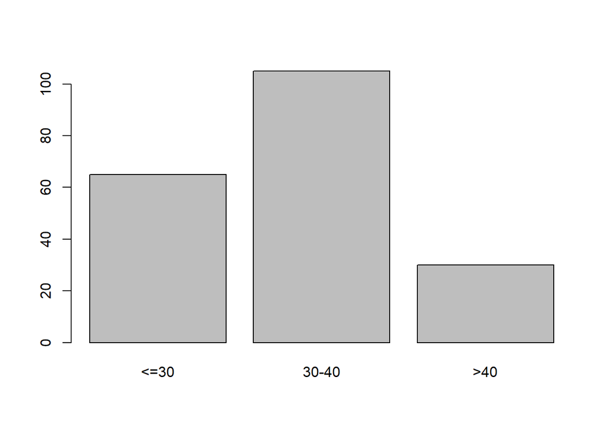

```r
barplot(table(data$edat_mare))
```

Gràfic de barres de les freqüències relatives

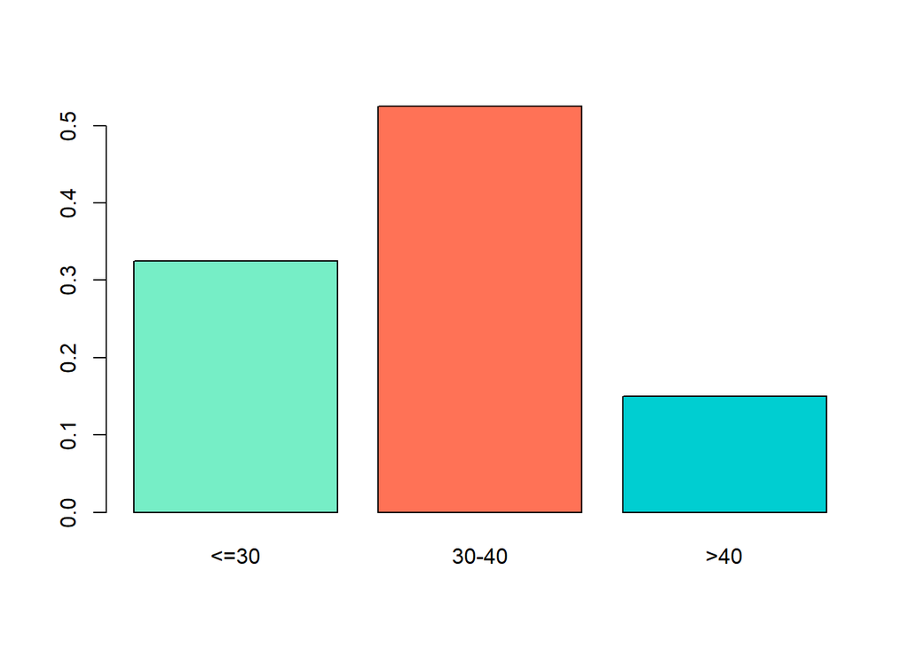

```r
barplot(prop.table(table(data$edat_mare)),
        col=c("aquamarine2", "coral1","darkturquoise"))
```

## 2.10 Variables comptatge (recompte)

Mirar si alguna de les variables són comptatges (recomptes) perquè requeriran una atenció especial.

Les variables comptatges es poden analitzar com si fossin numèriques o com categòriques i mirar quin dels dos anàlisis ens aporta més informació sobre la variable:

La variable “nombre_visites” és un recompte. La podem analitzar segons una variable numèrica:

```r
summary(data$nombre_visites)
```

```
##    Min. 1st Qu.  Median    Mean 3rd Qu.    Max.
##    0.00    2.00    3.00    3.72    4.00   20.00
```

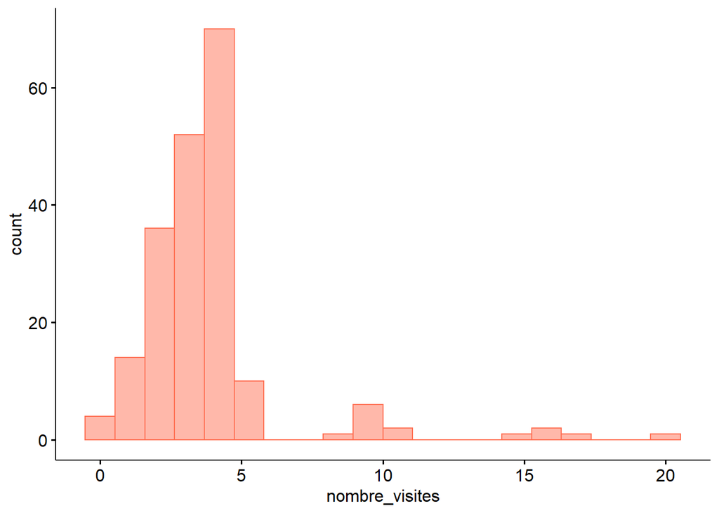

```r
gghistogram(data, x="nombre_visites",
               bins = 20,
               color = "coral1", fill = "coral1")
```

o com si fos categòrica:

```r
table(data$nombre_visites)
```

```
##
##  0  1  2  3  4  5  8  9 10 11 15 16 17 20
##  4 14 36 52 70 10  1  2  4  2  1  2  1  1
```

```r
prop.table(table(data$nombre_visites))
```

```
##
##     0     1     2     3     4     5     8     9    10    11    15    16    17
## 0.020 0.070 0.180 0.260 0.350 0.050 0.005 0.010 0.020 0.010 0.005 0.010 0.005
##    20
## 0.005
```

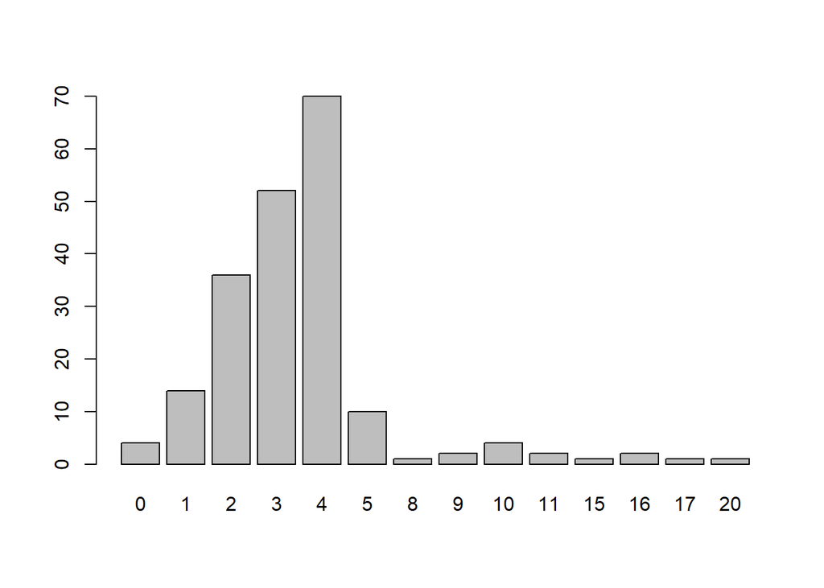

```r
barplot(table(data$nombre_visites))
```

i també la agrupar en noves categories:

Podem subdividir el nombre de visites en 2 categories: “<= 4” i “superiors a 4”

```r
data$visites_cat2<-cut(data$nombre_visites, c(0,4,20))

table(data$visites_cat2)
```

```
##
##  (0,4] (4,20]
##    172     24
```

```r
prop.table(table(data$visites_cat2))
```

```
##
##    (0,4]   (4,20]
## 0.877551 0.122449
```

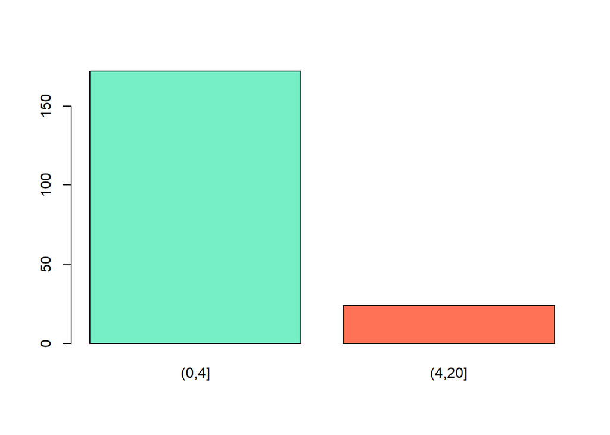

```r
barplot(table(data$visites_cat2),
        col=c("aquamarine2", "coral1"))
```

També podem subdividir el nombre de visites en 3 categories: “<=2”, “>2 i <=4” i “>4”:

```r
data$visites_cat3<-cut(data$nombre_visites, c(0,2,4,20))

table(data$visites_cat3)
```

```
##
##  (0,2]  (2,4] (4,20]
##     50    122     24
```

```r
prop.table(table(data$visites_cat3))
```

```
##
##    (0,2]    (2,4]   (4,20]
## 0.255102 0.622449 0.122449
```

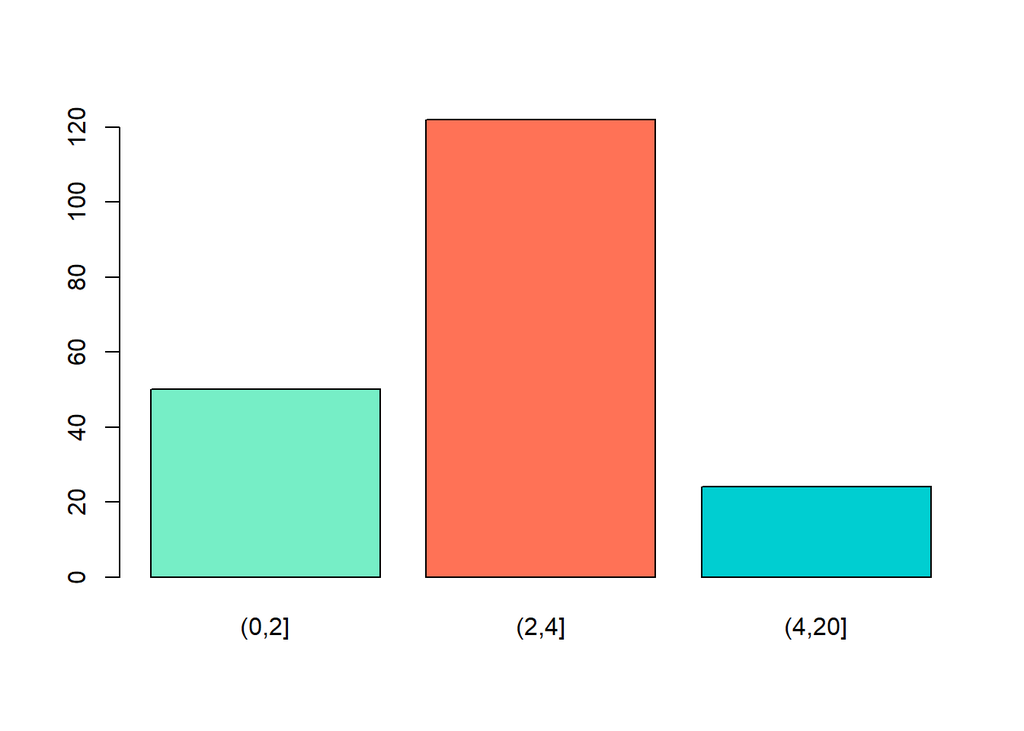

```r
barplot(table(data$visites_cat3),
        col=c("aquamarine2", "coral1","darkturquoise"))
```

## 2.11 Informe descripció inicial de les dades

Resum dels resultats obtinguts fins al moment:

És molt important tenir una bona descripció inicial de les dades que analitzarem. És recomanable fer un informe d’aquesta descripció inicial, tot i que aquesta part segurament no caldrà incloure-la a l’informe final (es pot afegir com a annex).

En aquesta fase es poden detectar possibles valors anòmals i decidir què fer amb ells. En general, eliminar valors no és una opció acceptable, llevat que es tracti de valors extremadament diferents de la majoria i que distorsionen molt els resultats. Si es decideix eliminar algun valor cal fer-ho de manera transparent i, en tot cas, informar d’aquest fet.

# 3 Analisi de les dades

Concretar i prioritzar els objectius:

- Definir l’objectiu principal de l’estudi
  - Identificar els factors associats al baix pes dels nens
- Identificar la variable principal de l’estudi (outcome)
  - Variables principals: “nado_pes”, “nado_baix_pes”
- Definir objectius que involucrin dues variables i mirar de quin tipus són:
  - Quin és l’efecte de l’edat de la mare sobre el pes del nadó?

    ```
      "edat_mare" (categòrica) i "nado_pes" (numèrica)

      "edat_mare" (categòrica) i "nado_baix_pes" (categòrica)
    ```

  - Hi ha relació entre el fet que la mare fumi i el pes del nadó?

    ```
      "mare_fumadora" (categòrica) i "nado_pes" (numèrica)

      "mare_fumadora" (categòrica) i "nado_baix_pes" (categòrica)
    ```

  - Quin és l’efecte del nombre de setmanes de gestació sobre el pes del nadó?

    ```
      "setmanes_gestacio" (numèrica) i "nado_pes" (numèrica)

      "setmanes_gestacio" (numèrica) i "nado_baix_pes" (categòrica)
    ```

- Definir objectius que involucrin més de dues variables.
  - Quin és l’efecte de l’edat de la mare sobre el pes del nadó en funció de si fuma o no fuma?

    ```
      "edat_mare" (categòrica),  "mare_fumadora" (categòrica) i "nado_pes" (numèrica)
      "edat_mare" (categòrica),  "mare_fumadora" (categòrica) i "nado_baix_pes" (categòrica)
    ```

# 4 Anàlisi relació dues var. numèriques

**Exemple: Analitzar la possible relació entre el nombre de setmanes de gestació i el pes dels nadons**

“setmanes_gestacio” (numèrica) i “nado_pes” (numèrica)

Fem un diagrama de punts (scatter plot):

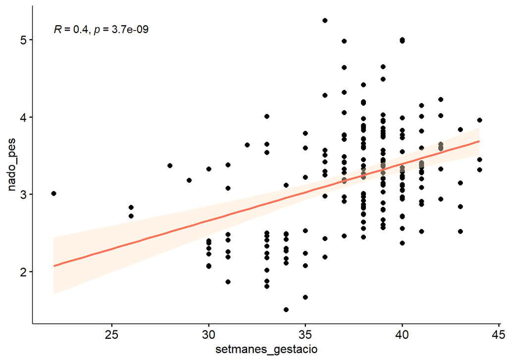

```r
ggscatter(data, x = "setmanes_gestacio", y = "nado_pes",
          add = "reg.line",                                      # regression line
          conf.int = TRUE,                                       # confidence interval
          add.params = list(color = "coral1", fill = "bisque")   # color
)+
  stat_cor(method = "pearson")      # correlation coefficient
```

# 5 Anàlisi relació var. numèrica i var.categòria

## 5.1 Histograma de la var. numèrica en funció de la categòrica

**Exemple: Analitzar la possible relació entre el nombre de setmanes de gestació i que el nadó tingui baix pes o no**

“setmanes_gestacio” (numèrica) i “nado_baix_pes” (categòrica)

Fem l’histograma posant la variable numèrica a la “x” i la categòrica a “color”:

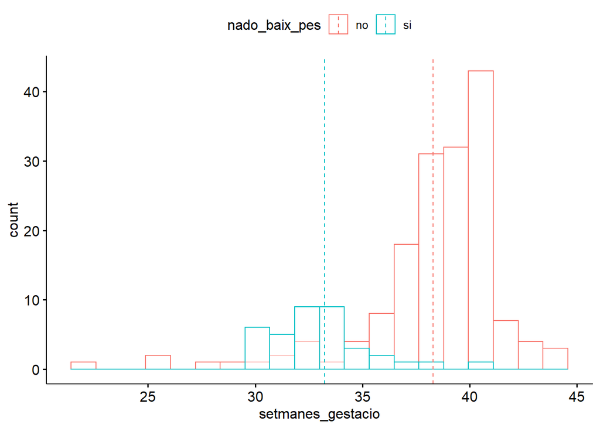

```r
gghistogram(data,
            x="setmanes_gestacio",
            color="nado_baix_pes",
            add = "mean",
            bins = 20)
```

## 5.2 Boxplot de la var. numèrica en funció de la categòrica

**Exemple: Analitzar la possible relació entre el nombre de setmanes de gestació i que el nadó tingui baix pes o no**

“setmanes_gestacio” (numèrica) i “nado_baix_pes” (categòrica)

Fem el gràfic de caixes múltiple posant la variable numèrica a la “y” i la categòrica a la “x”:

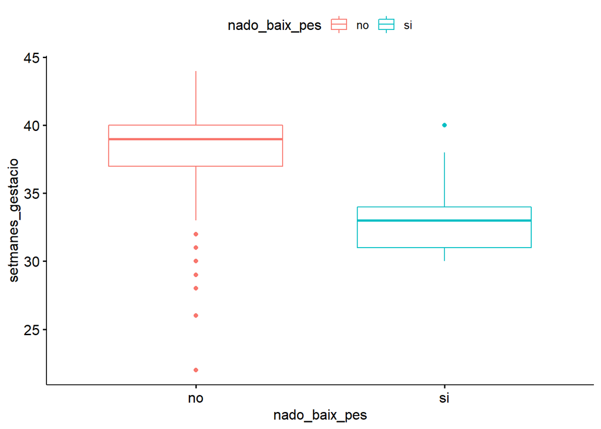

```r
boxp<-ggboxplot(data,
            y="setmanes_gestacio",
            x="nado_baix_pes",
            color = "nado_baix_pes",
            )

boxp
```

## 5.3 Resum de la variable numèrica en funció de les categories

**Exemple: Analitzar la possible relació entre el nombre de setmanes de gestació i que el nadó tingui baix pes o no**

“setmanes_gestacio” (numèrica) i “nado_baix_pes” (categòrica)

El resum numèric es pot fer de dues maneres, amb la funció `tapply()`:

```r
tapply(data$setmanes_gestacio, data$nado_baix_pes, summary)
```

```
## $no
##    Min. 1st Qu.  Median    Mean 3rd Qu.    Max.
##    22.0    37.0    39.0    38.3    40.0    44.0
##
## $si
##    Min. 1st Qu.  Median    Mean 3rd Qu.    Max.
##   30.00   31.00   33.00   33.24   34.00   40.00
```

o amb la funció `desc_statby()` de la llibreria **ggpubr**:

```r
desc_statby(data,"setmanes_gestacio", "nado_baix_pes") # amb la funció desc_statby de ggpubr
```

```
##   nado_baix_pes length min max median     mean iqr    mad       sd        se
## 1            no    163  22  44     39 38.30061   3 1.4826 3.233954 0.2533028
## 2            si     37  30  40     33 33.24324   3 2.9652 2.361796 0.3882768
##          ci range         cv       var
## 1 0.5002010    22 0.08443608 10.458456
## 2 0.7874618    10 0.07104588  5.578078
```

# 6 Proves d’hipòtesis d’igualtat de mitjanes

Si les dades en cada categoria són normals (p-valor shapiro test >= alpha) apliquem:

- t.test (2 categories)
- anova (> 2 categories)

Si les dades en cada categoria no són normals (p-valor shapiro test < alpha) apliquem:

- wilcoxon test (2 categories)
- Kruskal-wallis (> 2 categories)

**Exemple1: Analitzar la possible relació entre el nombre de setmanes de gestació i que el nadó tingui baix pes o no**

“setmanes_gestacio” (numèrica) i “nado_baix_pes” (categòrica)

Apliquem el test de normalitat:

```r
tapply(data$setmanes_gestacio, data$nado_baix_pes, function(x) shapiro.test(x))
```

```
## $no
##
##  Shapiro-Wilk normality test
##
## data:  x
## W = 0.8354, p-value = 2.893e-12
##
##
## $si
##
##  Shapiro-Wilk normality test
##
## data:  x
## W = 0.92247, p-value = 0.01319
```

Com que les dades no segueixen una distribució normal apliquem el test de Wilcoxon d’igualtat de dues mitjanes:

```r
wilcox.test(data$setmanes_gestacio~data$nado_baix_pes)
```

```
##
##  Wilcoxon rank sum test with continuity correction
##
## data:  data$setmanes_gestacio by data$nado_baix_pes
## W = 5457.5, p-value = 1.066e-14
## alternative hypothesis: true location shift is not equal to 0
```

**Exemple2: Analitzar la possible relació entre el pes inicial de la mare i que el nadó tingui baix pes o no**

“mare_pes_ini” (numèrica) i “nado_baix_pes” (categòrica):

Apliquem el test de normalitat:

```r
tapply(data$mare_pes_ini, data$nado_baix_pes, function(x) shapiro.test(x))
```

```
## $no
##
##  Shapiro-Wilk normality test
##
## data:  x
## W = 0.98949, p-value = 0.2677
##
##
## $si
##
##  Shapiro-Wilk normality test
##
## data:  x
## W = 0.97341, p-value = 0.5082
```

Com que les dades són normals, podrem aplicar el t-test per comparar les mitjanes. Però prèviament necessitem verificar si les variàncies són iguals o no:

```r
var.test(data$mare_pes_ini~data$nado_baix_pes)
```

```
##
##  F test to compare two variances
##
## data:  data$mare_pes_ini by data$nado_baix_pes
## F = 1.6908, num df = 162, denom df = 36, p-value = 0.06545
## alternative hypothesis: true ratio of variances is not equal to 1
## 95 percent confidence interval:
##  0.9658489 2.7172032
## sample estimates:
## ratio of variances
##           1.690776
```

Apliquem el t-test amb variàncies iguals:

```r
t.test(data$mare_pes_ini~data$nado_baix_pes, var.equal=T)
```

```
##
##  Two Sample t-test
##
## data:  data$mare_pes_ini by data$nado_baix_pes
## t = -1.5509, df = 198, p-value = 0.1225
## alternative hypothesis: true difference in means is not equal to 0
## 95 percent confidence interval:
##  -3.1777358  0.3798582
## sample estimates:
## mean in group no mean in group si
##         64.73620         66.13514
```

**Exemple 3: Analitzar la possible relació entre l’edat de la mare i el pes del nadó**

“edat_mare” (categòrica) i “nado_pes” (numèrica)

Comprovem si les dades són normals:

```r
tapply(data$nado_pes, data$edat_mare, function(x) shapiro.test(x))
```

```
## $`<=30`
##
##  Shapiro-Wilk normality test
##
## data:  x
## W = 0.96744, p-value = 0.08446
##
##
## $`30-40`
##
##  Shapiro-Wilk normality test
##
## data:  x
## W = 0.9862, p-value = 0.3518
##
##
## $`>40`
##
##  Shapiro-Wilk normality test
##
## data:  x
## W = 0.95714, p-value = 0.2614
```

Abans d’aplicar l’ANOVA cal comprovar si les variàncies dels diferents grups es poden considerar iguals:

```r
#install.packages("lmtest")

library(lmtest)

bptest(lm(data$nado_pes ~data$edat_mare),studentize = FALSE)
```

```
##
##  Breusch-Pagan test
##
## data:  lm(data$nado_pes ~ data$edat_mare)
## BP = 0.90261, df = 2, p-value = 0.6368
```

Podem aplicar l’ANOVA per comparar les mitjanes de pes dels 3 grups d’edat:

```r
summary(aov(data$nado_pes~data$edat_mare))
```

```
##                 Df Sum Sq Mean Sq F value Pr(>F)
## data$edat_mare   2   0.17  0.0848   0.188  0.828
## Residuals      197  88.67  0.4501
```

La conclusió és que no hi ha diferències. Si n’hi haguéssin aplicaríem un test per determinar quins grups tenen mitjanes diferents:

```r
TukeyHSD(aov(data$nado_pes~data$edat_mare))
```

```
##   Tukey multiple comparisons of means
##     95% family-wise confidence level
##
## Fit: aov(formula = data$nado_pes ~ data$edat_mare)
##
## $`data$edat_mare`
##                   diff        lwr       upr     p adj
## 30-40-<=30 0.006241758 -0.2438059 0.2562894 0.9980859
## >40-<=30   0.085051282 -0.2646475 0.4347501 0.8339475
## >40-30-40  0.078809524 -0.2491809 0.4068000 0.8375801
```

**Exemple 4: Analitzar la possible relació entre l’edat de la mare i el nombre de setmanes de gestació**

“edat_mare” (categòrica) i “setmanes_gestacio” (numèrica)

Comprovem si les dades són normals:

```r
tapply(data$setmanes_gestacio, data$edat_mare, function(x) shapiro.test(x))
```

```
## $`<=30`
##
##  Shapiro-Wilk normality test
##
## data:  x
## W = 0.89778, p-value = 5.835e-05
##
##
## $`30-40`
##
##  Shapiro-Wilk normality test
##
## data:  x
## W = 0.92059, p-value = 9.623e-06
##
##
## $`>40`
##
##  Shapiro-Wilk normality test
##
## data:  x
## W = 0.90979, p-value = 0.0147
```

Com que no es verifica la condició de normalitat apliquem el test de Kruskal-Wallis per comparar les mitjanes dels 3 grups:

```r
kruskal.test(data$setmanes_gestacio~data$edat_mare)
```

```
##
##  Kruskal-Wallis rank sum test
##
## data:  data$setmanes_gestacio by data$edat_mare
## Kruskal-Wallis chi-squared = 0.97933, df = 2, p-value = 0.6128
```

# 7 Anàlisi relació dues var. categòriques

**Exemple: Analitzar la possible relació entre el fet que la mare fumi i que el nadó tingui baix pes o no**

“mare_fumadora” (categòrica) i “nado_baix_pes” (categòrica)

Comencem fent la taula de freqüències i la taula de freqüències relatives per files:

```r
freq<-table(data$mare_fumadora, data$nado_baix_pes)
freqbyrow<-prop.table(table(data$mare_fumadora, data$nado_baix_pes),1)
```

Convertim la taula de freqüències per files en un data frame i posem bé el nom de les variables:

```r
freqbyrow<-as.data.frame(freqbyrow)                  # transform the table into a data frame
freqbyrow
```

```
##   Var1 Var2    Freq
## 1   no   no 0.89375
## 2   si   no 0.50000
## 3   no   si 0.10625
## 4   si   si 0.50000
```

```r
colnames(freqbyrow)<-c("mare_fumadora","nado_baix_pes","Freq")
freqbyrow
```

```
##   mare_fumadora nado_baix_pes    Freq
## 1            no            no 0.89375
## 2            si            no 0.50000
## 3            no            si 0.10625
## 4            si            si 0.50000
```

Fem el gràfic de barres de la taula de freqüències per files:

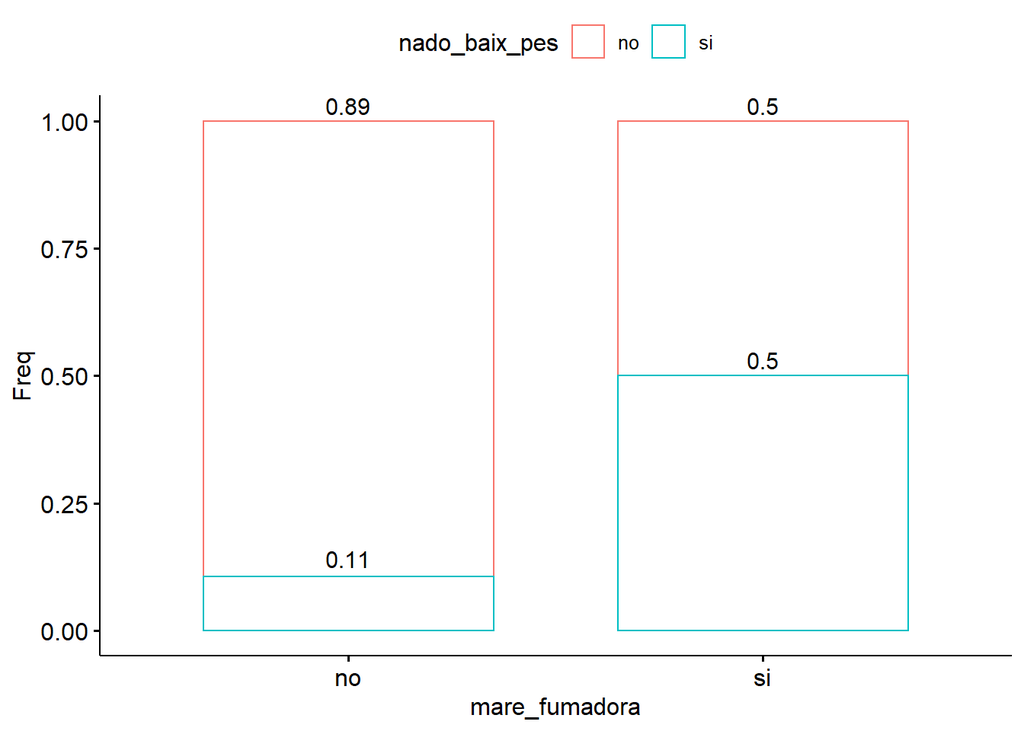

```r
ggbarplot(freqbyrow, x="mare_fumadora", y="Freq",       # x = variable files de la taula
          color = "nado_baix_pes",
          label = TRUE,
          lab.nb.digits = 2)                    # nombre de dígits de les proporcions
```

Apliquem la prova xi-quadrat d’independència entre dos factors:

```r
chisq.test(freq)
```

```
##
##  Pearson's Chi-squared test with Yates' continuity correction
##
## data:  freq
## X-squared = 30.345, df = 1, p-value = 3.616e-08
```

Quan la taula de freqüències és 2x2 podem aplicar el test de Fisher:

```r
fisher.test(freq)
```

```
##
##  Fisher's Exact Test for Count Data
##
## data:  freq
## p-value = 1.864e-07
## alternative hypothesis: true odds ratio is not equal to 1
## 95 percent confidence interval:
##   3.49944 20.11074
## sample estimates:
## odds ratio
##   8.280577
```

De vegades pot ser interessant mesurar el grau d’associació entre dos variables categòriques. Una possible mesura d’associació és la V de Cramer:

```r
library(rcompanion)
cramerV(data$mare_fumadora, data$nado_baix_pes, bias.correct = T)
```

```
## Cramer V
##   0.4004
```

# 8 Models de regressió

Els models de regressió són útils per estudiar la relació d’una o més variables sobre una variable d’interès (*variable resposta*).

## 8.1 Regressió lineal

El model de regressió lineal s’utilitza quan la variable resposta és numèrica (contínua):

**Exemple: Quin és l’efecte de l’edat i el pes inicial de la mare sobre el pes del nadó en funció de si fuma o no fuma?**

y = “nado_pes” (numèrica)

x1 = “edat_mare” (categòrica), x2 = “mare_fumadora” (categòrica), x3 = “mare_pes_ini”

```r
model1<-lm(nado_pes~mare_fumadora+edat_mare+mare_pes_ini, data = data)
summary(model1)
```

```
##
## Call:
## lm(formula = nado_pes ~ mare_fumadora + edat_mare + mare_pes_ini,
##     data = data)
##
## Residuals:
##      Min       1Q   Median       3Q      Max
## -1.75729 -0.41119 -0.03987  0.42235  1.91645
##
## Coefficients:
##                  Estimate Std. Error t value Pr(>|t|)
## (Intercept)      3.783093   0.587203   6.443 8.98e-10 ***
## mare_fumadorasi -0.587786   0.111838  -5.256 3.85e-07 ***
## edat_mare30-40  -0.007793   0.100558  -0.078    0.938
## edat_mare>40     0.118196   0.139082   0.850    0.396
## mare_pes_ini    -0.007362   0.009093  -0.810    0.419
## ---
## Signif. codes:  0 '***' 0.001 '**' 0.01 '*' 0.05 '.' 0.1 ' ' 1
##
## Residual standard error: 0.6294 on 195 degrees of freedom
## Multiple R-squared:  0.1304, Adjusted R-squared:  0.1126
## F-statistic: 7.313 on 4 and 195 DF,  p-value: 1.655e-05
```

**Cal comprovar que es compleixen els requisits de la regressió lineal:**

- Normalitat dels residus:

```r
shapiro.test(residuals(model1))
```

```
##
##  Shapiro-Wilk normality test
##
## data:  residuals(model1)
## W = 0.99039, p-value = 0.2037
```

- Els residus estan centrats al voltant del zero:

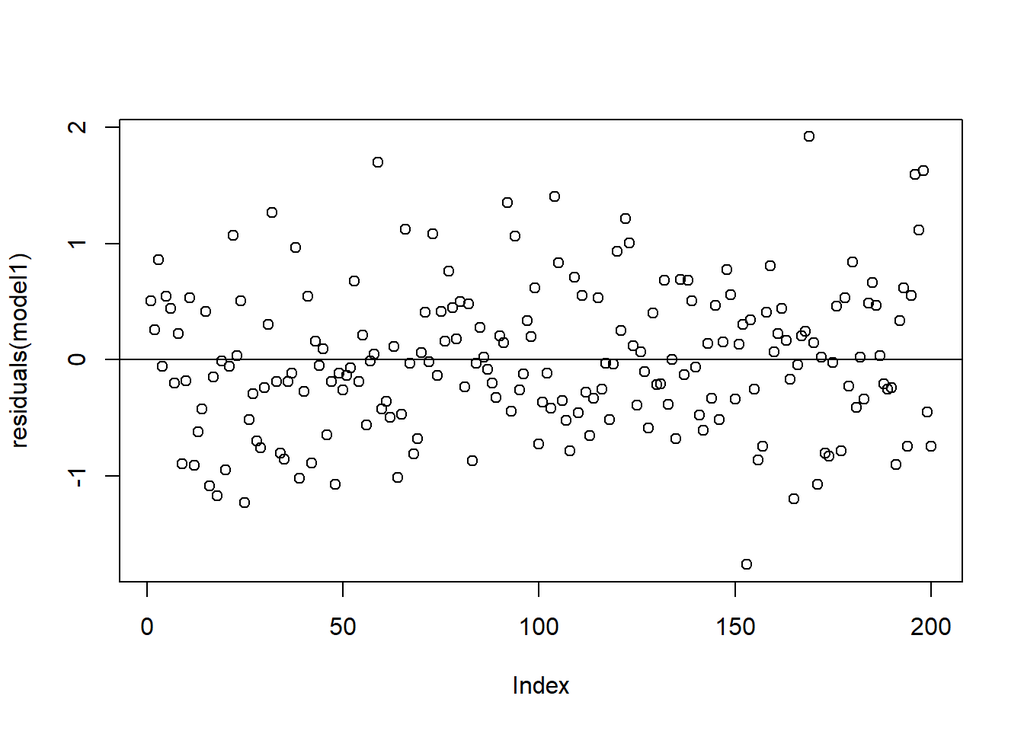

```r
plot(residuals(model1))
abline(a=0, b=0)
```

## 8.2 Regressió logística

El model de regressió logística s’utilitza quan la variable resposta és binària (categòrica, amb dues categories):

**Exemple: Quin és l’efecte de l’edat de la mare en el risc que el nen tingui baix pes en funció de si la mare fuma o no fuma?**

y = “nado_baix_pes” (binària)

x1=“edat_mare” (categòrica), x2=“mare_fumadora” (categòrica)

```r
model2<-glm(nado_baix_pes~mare_fumadora+edat_mare, data = data, family = "binomial")
summary(model2)
```

```
##
## Call:
## glm(formula = nado_baix_pes ~ mare_fumadora + edat_mare, family = "binomial",
##     data = data)
##
## Deviance Residuals:
##     Min       1Q   Median       3Q      Max
## -1.2062  -0.4861  -0.4614  -0.4540   2.1558
##
## Coefficients:
##                 Estimate Std. Error z value Pr(>|z|)
## (Intercept)     -2.18641    0.39274  -5.567 2.59e-08 ***
## mare_fumadorasi  2.14358    0.41060   5.221 1.78e-07 ***
## edat_mare30-40   0.11039    0.44787   0.246    0.805
## edat_mare>40    -0.03424    0.61464  -0.056    0.956
## ---
## Signif. codes:  0 '***' 0.001 '**' 0.01 '*' 0.05 '.' 0.1 ' ' 1
##
## (Dispersion parameter for binomial family taken to be 1)
##
##     Null deviance: 191.56  on 199  degrees of freedom
## Residual deviance: 163.71  on 196  degrees of freedom
## AIC: 171.71
##
## Number of Fisher Scoring iterations: 4
```

# 9 Selecció de variables: Step-wise regression

La selecció de variables s’utilitza per identificar quines variables estan més relacionades amb la variable d’interès.

**Exemple: Quines variables estan relacionades amb el pes del nadó?**

L’objectiu és identificar quines variables estan realment relacionades amb el pes del nadó i quines es poden eliminar del model. Afegirem en l’anàlisi l’augment de pes de la mare durant l’embaràç:

```r
data$augment_pes<-data$mare_pes_fi-data$mare_pes_ini

model3<-lm(nado_pes~., data = data[, c(2,3,7,8,9,14)])
summary(model3)
```

```
##
## Call:
## lm(formula = nado_pes ~ ., data = data[, c(2, 3, 7, 8, 9, 14)])
##
## Residuals:
##      Min       1Q   Median       3Q      Max
## -1.68535 -0.39363 -0.04404  0.37876  2.00964
##
## Coefficients:
##                  Estimate Std. Error t value Pr(>|t|)
## (Intercept)      2.437544   0.202720  12.024  < 2e-16 ***
## nado_sexenena   -0.174646   0.084276  -2.072   0.0396 *
## edat_mare30-40   0.049287   0.093836   0.525   0.6000
## edat_mare>40     0.106804   0.129932   0.822   0.4121
## nombre_visites   0.007366   0.015220   0.484   0.6289
## mare_fumadorasi -0.508147   0.105874  -4.800 3.18e-06 ***
## augment_pes      0.065103   0.012075   5.391 2.03e-07 ***
## ---
## Signif. codes:  0 '***' 0.001 '**' 0.01 '*' 0.05 '.' 0.1 ' ' 1
##
## Residual standard error: 0.5877 on 193 degrees of freedom
## Multiple R-squared:  0.2497, Adjusted R-squared:  0.2264
## F-statistic: 10.71 on 6 and 193 DF,  p-value: 2.889e-10
```

Apliquem el mètode de selecció de variables (*step-wise regression*):

```r
step(model3)
```

```
## Start:  AIC=-205.77
## nado_pes ~ nado_sexe + edat_mare + nombre_visites + mare_fumadora +
##     augment_pes
##
##                  Df Sum of Sq    RSS     AIC
## - edat_mare       2    0.2457 66.896 -209.03
## - nombre_visites  1    0.0809 66.731 -207.53
## <none>                        66.651 -205.77
## - nado_sexe       1    1.4830 68.134 -203.37
## - mare_fumadora   1    7.9551 74.606 -185.22
## - augment_pes     1   10.0384 76.689 -179.71
##
## Step:  AIC=-209.03
## nado_pes ~ nado_sexe + nombre_visites + mare_fumadora + augment_pes
##
##                  Df Sum of Sq    RSS     AIC
## - nombre_visites  1    0.0866 66.983 -210.78
## <none>                        66.896 -209.03
## - nado_sexe       1    1.5094 68.406 -206.57
## - mare_fumadora   1    7.9952 74.891 -188.46
## - augment_pes     1   10.1911 77.087 -182.68
##
## Step:  AIC=-210.78
## nado_pes ~ nado_sexe + mare_fumadora + augment_pes
##
##                 Df Sum of Sq    RSS     AIC
## <none>                       66.983 -210.78
## - nado_sexe      1    1.4496 68.432 -208.49
## - mare_fumadora  1    7.9650 74.948 -190.31
## - augment_pes    1   10.1165 77.099 -184.65
```

```
##
## Call:
## lm(formula = nado_pes ~ nado_sexe + mare_fumadora + augment_pes,
##     data = data[, c(2, 3, 7, 8, 9, 14)])
##
## Coefficients:
##     (Intercept)    nado_sexenena  mare_fumadorasi      augment_pes
##         2.51355         -0.17157         -0.50559          0.06445
```

Veiem que el procediment de selecció de variables ha seleccionat el sexe del nadó, si la mare fuma i l’augment de pes de la mare com a variables rellevants en relació al pes del nadó. Fem un resum d’aquest model:

```r
summary(step(model3))
```

```
## Start:  AIC=-205.77
## nado_pes ~ nado_sexe + edat_mare + nombre_visites + mare_fumadora +
##     augment_pes
##
##                  Df Sum of Sq    RSS     AIC
## - edat_mare       2    0.2457 66.896 -209.03
## - nombre_visites  1    0.0809 66.731 -207.53
## <none>                        66.651 -205.77
## - nado_sexe       1    1.4830 68.134 -203.37
## - mare_fumadora   1    7.9551 74.606 -185.22
## - augment_pes     1   10.0384 76.689 -179.71
##
## Step:  AIC=-209.03
## nado_pes ~ nado_sexe + nombre_visites + mare_fumadora + augment_pes
##
##                  Df Sum of Sq    RSS     AIC
## - nombre_visites  1    0.0866 66.983 -210.78
## <none>                        66.896 -209.03
## - nado_sexe       1    1.5094 68.406 -206.57
## - mare_fumadora   1    7.9952 74.891 -188.46
## - augment_pes     1   10.1911 77.087 -182.68
##
## Step:  AIC=-210.78
## nado_pes ~ nado_sexe + mare_fumadora + augment_pes
##
##                 Df Sum of Sq    RSS     AIC
## <none>                       66.983 -210.78
## - nado_sexe      1    1.4496 68.432 -208.49
## - mare_fumadora  1    7.9650 74.948 -190.31
## - augment_pes    1   10.1165 77.099 -184.65
```

```
##
## Call:
## lm(formula = nado_pes ~ nado_sexe + mare_fumadora + augment_pes,
##     data = data[, c(2, 3, 7, 8, 9, 14)])
##
## Residuals:
##      Min       1Q   Median       3Q      Max
## -1.66988 -0.39415 -0.06879  0.39318  2.05793
##
## Coefficients:
##                 Estimate Std. Error t value Pr(>|t|)
## (Intercept)      2.51355    0.17321  14.511  < 2e-16 ***
## nado_sexenena   -0.17157    0.08330  -2.060   0.0408 *
## mare_fumadorasi -0.50559    0.10473  -4.828 2.78e-06 ***
## augment_pes      0.06445    0.01185   5.441 1.57e-07 ***
## ---
## Signif. codes:  0 '***' 0.001 '**' 0.01 '*' 0.05 '.' 0.1 ' ' 1
##
## Residual standard error: 0.5846 on 196 degrees of freedom
## Multiple R-squared:  0.246,  Adjusted R-squared:  0.2345
## F-statistic: 21.32 on 3 and 196 DF,  p-value: 5.417e-12
```